# IODS course project

## tea dataset

### Multiple Correspondence Analysis

```r
library(FactoMineR)
```

```r
library(magrittr)
library(MASS)
library(ggplot2)
library(tidyr)
library(corrplot)
library(GGally)
data(tea)
str(tea)
```

```
## 'data.frame':    300 obs. of  36 variables:
##  $ breakfast       : Factor w/ 2 levels "breakfast","Not.breakfast": 1 1 2 2 1 2 1 2 1 1 ...
##  $ tea.time        : Factor w/ 2 levels "Not.tea time",..: 1 1 2 1 1 1 2 2 2 1 ...
##  $ evening         : Factor w/ 2 levels "evening","Not.evening": 2 2 1 2 1 2 2 1 2 1 ...
##  $ lunch           : Factor w/ 2 levels "lunch","Not.lunch": 2 2 2 2 2 2 2 2 2 2 ...
##  $ dinner          : Factor w/ 2 levels "dinner","Not.dinner": 2 2 1 1 2 1 2 2 2 2 ...
##  $ always          : Factor w/ 2 levels "always","Not.always": 2 2 2 2 1 2 2 2 2 2 ...
##  $ home            : Factor w/ 2 levels "home","Not.home": 1 1 1 1 1 1 1 1 1 1 ...
##  $ work            : Factor w/ 2 levels "Not.work","work": 1 1 2 1 1 1 1 1 1 1 ...
##  $ tearoom         : Factor w/ 2 levels "Not.tearoom",..: 1 1 1 1 1 1 1 1 1 2 ...
##  $ friends         : Factor w/ 2 levels "friends","Not.friends": 2 2 1 2 2 2 1 2 2 2 ...
##  $ resto           : Factor w/ 2 levels "Not.resto","resto": 1 1 2 1 1 1 1 1 1 1 ...
##  $ pub             : Factor w/ 2 levels "Not.pub","pub": 1 1 1 1 1 1 1 1 1 1 ...
##  $ Tea             : Factor w/ 3 levels "black","Earl Grey",..: 1 1 2 2 2 2 2 1 2 1 ...
##  $ How             : Factor w/ 4 levels "alone","lemon",..: 1 3 1 1 1 1 1 3 3 1 ...
```

[output cut: 22 more lines]

```r
dim(tea)
```

```
## [1] 300  36
```

```r
#The tea dataset has 300 observations and 36 variables.
```

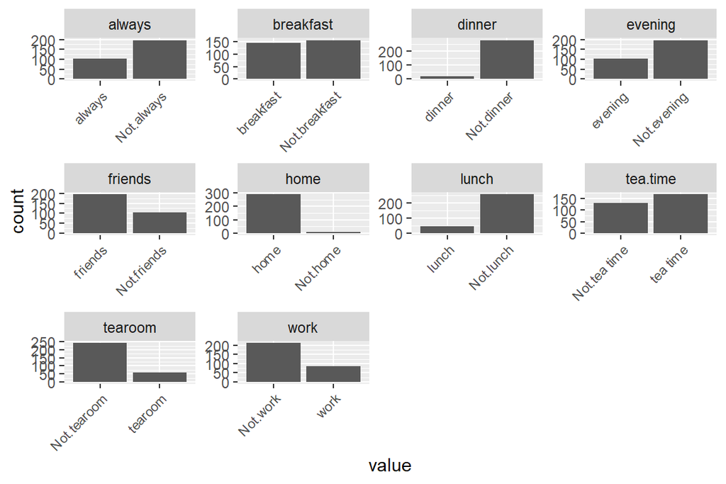

```r
# visualize the dataset
#Because there are so many variables, it's easier to separate them.

tidyr::gather(tea[1:10]) %>% ggplot(aes(value)) + facet_wrap("key", scales = "free") + geom_bar() + theme(axis.text.x = element_text(angle = 45, hjust = 1, size = 8))
```

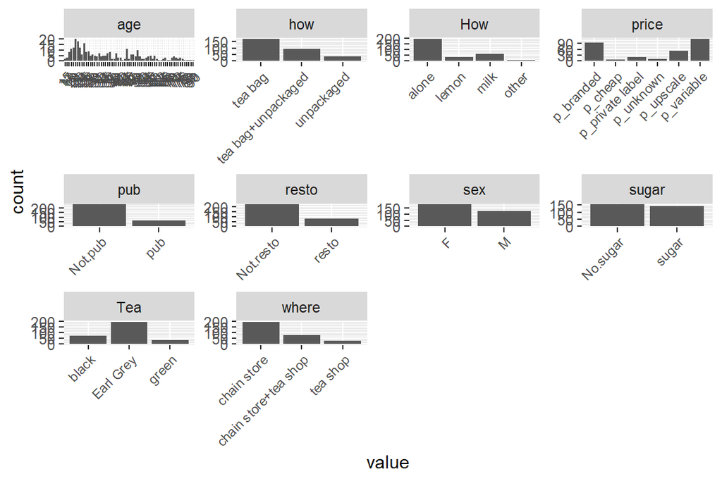

```r
tidyr::gather(tea[11:20]) %>% ggplot(aes(value)) + facet_wrap("key", scales = "free") + geom_bar() + theme(axis.text.x = element_text(angle = 45, hjust = 1, size = 8))
```

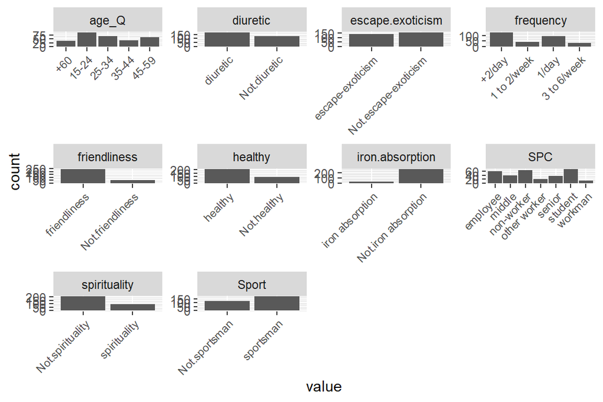

```r
tidyr::gather(tea[21:30]) %>% ggplot(aes(value)) + facet_wrap("key", scales = "free") + geom_bar() + theme(axis.text.x = element_text(angle = 45, hjust = 1, size = 8))
```

We have logical variables such as “healthy” or “no healthy” in the data, as well as factor variables with varied degrees. MCA (Multiple Correspondence Analysis) is a qualitative data analysis method that is an extension of Correspondence Analysis (CA). MCA can be used to find patterns or organization in data, as well as to reduce the number of dimensions.

```r
#I'll use fewer variables for the purpose of simplicity.

# column names to keep in the dataset
keep_columns <- c("Tea", "How", "healthy", "sugar", "where", "lunch", "sex")

# select the 'keep_columns' to create a new dataset
tea_time <- dplyr::select(tea, one_of(keep_columns))
# multiple correspondence analysis
mca <- MCA(tea_time, graph = FALSE)

# summary of the model
summary(mca)
```

```
##
## Call:
## MCA(X = tea_time, graph = FALSE)
##
##
## Eigenvalues
##                        Dim.1   Dim.2   Dim.3   Dim.4   Dim.5   Dim.6   Dim.7
## Variance               0.201   0.192   0.183   0.167   0.153   0.145   0.121
## % of var.             12.807  12.231  11.615  10.622   9.749   9.198   7.681
## Cumulative % of var.  12.807  25.038  36.654  47.276  57.025  66.224  73.905
##                        Dim.8   Dim.9  Dim.10  Dim.11
## Variance               0.119   0.107   0.102   0.082
## % of var.              7.585   6.782   6.486   5.244
## Cumulative % of var.  81.489  88.271  94.756 100.000
##
## Individuals (the 10 first)
##                Dim.1    ctr   cos2    Dim.2    ctr   cos2    Dim.3    ctr
## 1           | -0.041  0.003  0.002 | -0.308  0.164  0.091 |  0.310  0.176
## 2           |  0.559  0.517  0.228 | -0.188  0.061  0.026 |  0.001  0.000
## 3           |  0.187  0.058  0.063 | -0.167  0.048  0.050 | -0.550  0.553
## 4           | -0.412  0.281  0.248 | -0.054  0.005  0.004 |  0.035  0.002
## 5           | -0.326  0.176  0.114 | -0.214  0.080  0.049 | -0.228  0.095
## 6           | -0.041  0.003  0.003 | -0.287  0.143  0.124 | -0.133  0.032
## 7           | -0.041  0.003  0.003 | -0.287  0.143  0.124 | -0.133  0.032
## 8           |  0.559  0.517  0.228 | -0.188  0.061  0.026 |  0.001  0.000
## 9           | -0.028  0.001  0.000 |  0.393  0.267  0.089 |  0.258  0.122
## 10          |  0.628  0.653  0.292 | -0.166  0.048  0.021 |  0.353  0.228
##               cos2
## 1            0.093 |
## 2            0.000 |
## 3            0.547 |
## 4            0.002 |
## 5            0.055 |
## 6            0.027 |
## 7            0.027 |
## 8            0.000 |
## 9            0.039 |
## 10           0.093 |
##
## Categories (the 10 first)
```

[output cut: 17 more lines]

```
## milk        |   0.417   2.857   0.046   3.717 |
## other       |   1.330   4.154   0.055   4.045 |
## healthy     |   0.085   0.397   0.017   2.248 |
## Not.healthy |  -0.199   0.926   0.017  -2.248 |
## No.sugar    |  -0.242   2.369   0.063  -4.327 |
##
## Categorical variables (eta2)
##               Dim.1 Dim.2 Dim.3
## Tea         | 0.255 0.459 0.133 |
## How         | 0.322 0.231 0.368 |
## healthy     | 0.168 0.011 0.017 |
## sugar       | 0.338 0.128 0.063 |
## where       | 0.190 0.379 0.312 |
## lunch       | 0.012 0.105 0.008 |
## sex         | 0.124 0.033 0.376 |
```

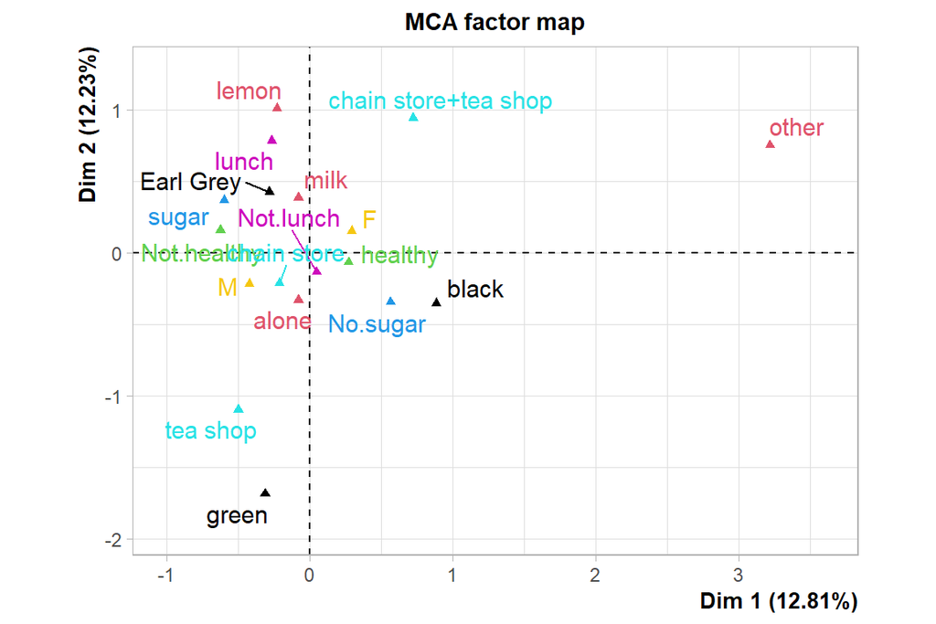

```r
# visualize MCA
plot(mca, invisible=c("ind"), habillage = "quali")
```

# 6. **Analysis of longitudinal data**

The examples from Vehkalahti and Everitt’s (2019) book Multivariate Analysis for the Behavioral Sciences will be repeated, but the data sets will be swapped between the chapters. Each male subject was scored on the brief psychiatric rating scale (BPRS) before therapy began (week 0) and then at weekly intervals for eight weeks. The BPRS rates the severity of 18 symptom components, including aggression, suspiciousness, hallucinations, and grandiosity, on a scale of one to seven (extremely severe). The scale is used to assess patients who may be suffering from schizophrenia.

But first we are going to focus on the RATS dataset. The RATS dataset is described as follows in the book: We shall use some data from a nutrition study conducted on three groups of rats.(Crowder and Hand, 1990). The three groups were put on different diets, and each animal’s body weight (grams) was recorded repeatedly (approximately weekly, except in week seven when two recordings were taken) over a 9-week period.

```r
library(dplyr)
library(ggplot2)

RATS <- read.csv("data/rats.csv")
RATS$ID <- as.factor(RATS$ID)
RATS$Group <- as.factor(RATS$Group)
str(RATS)
```

```
## 'data.frame':    176 obs. of  5 variables:
##  $ ID    : Factor w/ 16 levels "1","2","3","4",..: 1 2 3 4 5 6 7 8 9 10 ...
##  $ Group : Factor w/ 3 levels "1","2","3": 1 1 1 1 1 1 1 1 2 2 ...
##  $ WD    : chr  "WD1" "WD1" "WD1" "WD1" ...
##  $ weight: int  240 225 245 260 255 260 275 245 410 405 ...
##  $ time  : int  1 1 1 1 1 1 1 1 1 1 ...
```

```r
summary(RATS)
```

```
##        ID      Group       WD                weight           time
##  1      : 11   1:88   Length:176         Min.   :225.0   Min.   : 1.00
##  2      : 11   2:44   Class :character   1st Qu.:267.0   1st Qu.:15.00
##  3      : 11   3:44   Mode  :character   Median :344.5   Median :36.00
##  4      : 11                             Mean   :384.5   Mean   :33.55
##  5      : 11                             3rd Qu.:511.2   3rd Qu.:50.00
##  6      : 11                             Max.   :628.0   Max.   :64.00
##  (Other):110
```

```r
#(The dataset has already been converted to a long form.)
```

We can see that there are 16 rats (the highest number of ID is 16 as each rat has a own ID number).

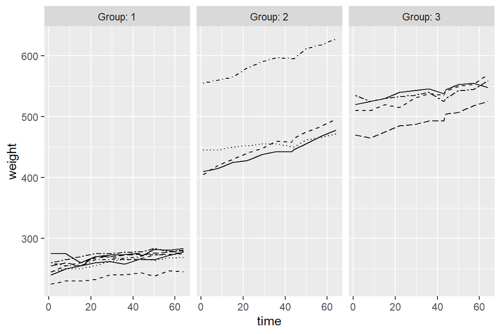

```r
ggplot(RATS, aes(x = time, y = weight, linetype= ID)) +
  geom_line() +
  scale_linetype_manual(values = rep(1:8, 2)) +
  facet_grid(. ~ Group, labeller=label_both) +
  theme(legend.position = "none") +
  scale_y_continuous(limits = c(min(RATS$weight), max(RATS$weight)))
```

The rats in Group 1 appear to be the tiniest. We can observe in group 2 that there is a one giant rat. The group of three rats appears to be larger as well.

## The Golden Standardise

It is possible that rats that have high weights at the beginning of the study tend to have higher weights throughout the study.

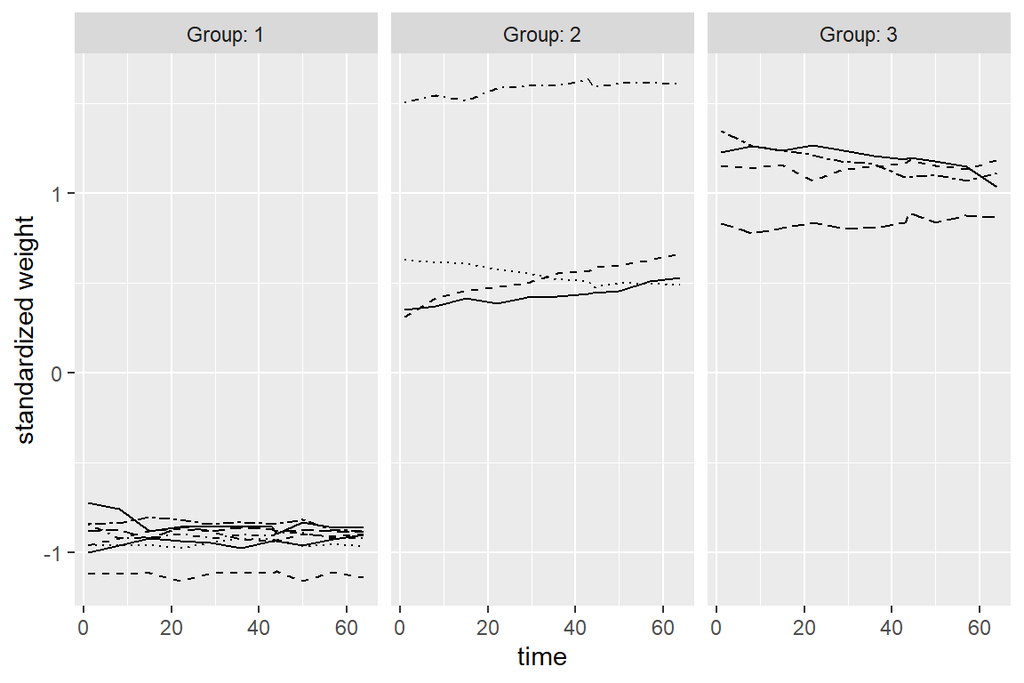

```r
rats_tracked <- RATS %>%
  group_by(time) %>%
  mutate(std.weight = (weight - mean(weight))/sd(weight)) %>%
  ungroup()


ggplot(rats_tracked, aes(x = time, y = std.weight, linetype= ID)) +
  geom_line() +
  scale_linetype_manual(values = rep(1:8, 2)) +
  facet_grid(. ~ Group, labeller=label_both) +
  theme(legend.position = "none") +
  scale_y_continuous("standardized weight")
```

It is easier to compare how the rats gained weight compared to the other rats. In the plot before, it looked like the rats were steadily gaining weight. However, in the new plot, we can see that it was not true for all cases. It seems like the rats starting weight contributes to the later weight. The next step is to check for outliers in more detail. Instead of individual profiles, graphs depicting average (mean) profiles for each group are frequently beneficial to detect outliers.

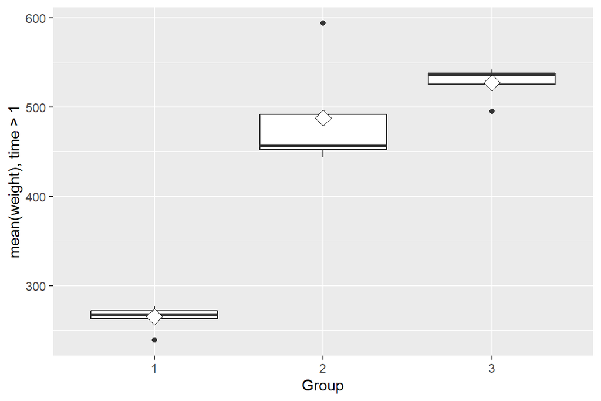

```r
# Create a summary data by treatment and subject with mean as the summary variable
RATS_M <- RATS %>%
  filter(time > 1) %>%
  group_by(Group, ID) %>%
  summarise( mean=mean(weight), .groups="keep" ) %>%
  ungroup()

# Plot the mean profiles

ggplot(RATS_M, aes(x = Group, y = mean)) +
  geom_boxplot() +
  stat_summary(fun = "mean", geom = "point", shape=23, size=4, fill = "white") +
  scale_y_continuous(name = "mean(weight), time > 1")
```

It is clear that the group 2 has an outlier. Let us remove this outlier. It is though important to keep in mind that the sample size drops a lot.

```r
glimpse(RATS_M)
```

```
## Rows: 16
## Columns: 3
## $ Group <fct> 1, 1, 1, 1, 1, 1, 1, 1, 2, 2, 2, 2, 3, 3, 3, 3
## $ ID    <fct> 1, 2, 3, 4, 5, 6, 7, 8, 9, 10, 11, 12, 13, 14, 15, 16
## $ mean  <dbl> 263.2, 238.9, 261.7, 267.2, 270.9, 276.2, 274.6, 267.5, 443.9, 4~
```

```r
#let check which outliers we should remove
RATS_M$mean
```

```
##  [1] 263.2 238.9 261.7 267.2 270.9 276.2 274.6 267.5 443.9 457.5 455.8 594.0
## [13] 495.2 536.4 542.2 536.2
```

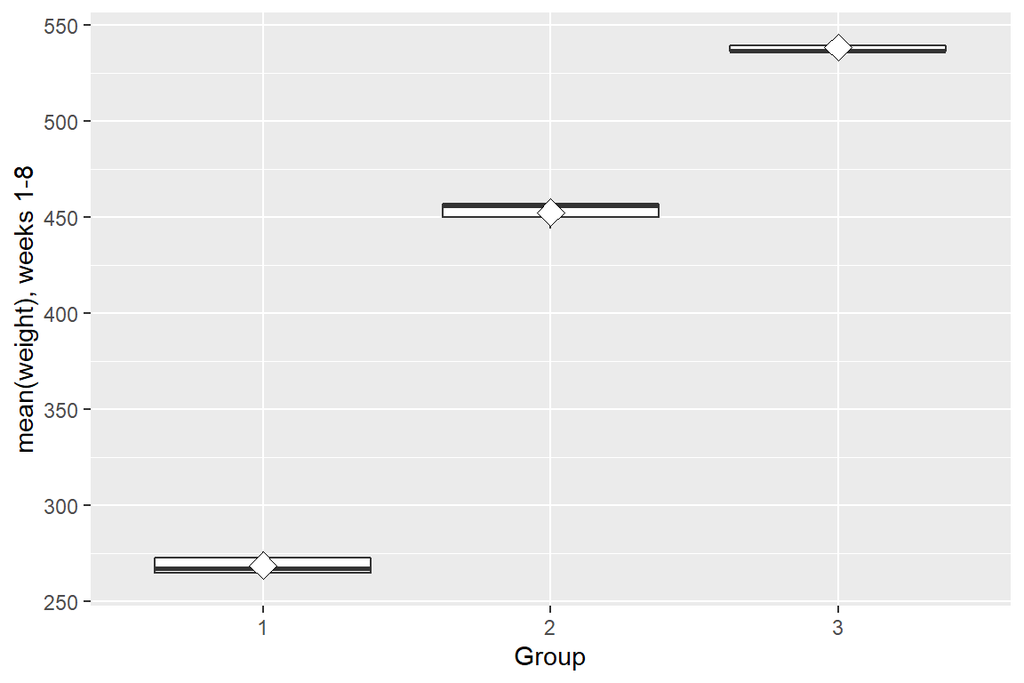

```r
#Create new data by removing the outliers.

RATSW <- filter(RATS_M, mean != 238.9, mean != 594.0, mean != 495.2)

ggplot(RATSW, aes(x = Group, y = mean)) +
  geom_boxplot() +
  stat_summary(fun.y = "mean", geom = "point", shape=23, size=4, fill = "white") +
  scale_y_continuous(name = "mean(weight), weeks 1-8")
```

## t-test and anova

The groups are quite different after the outliers are removed. The graphs created earlier in this lesson show that there is a distinction between the three groups. An anova test is used to formally test the difference between the groups. The t-test used in the reference material (MABS) cannot be used since only two samples can be used in the t-test. However, t-test can be performed for each group separately. The data from the previous exercise is used without the outliers in the t-test.

```r
RATS_M1 <- RATSW %>% filter(Group != 3)
t.test(mean ~ Group, data = RATS_M1, var.equal = TRUE)
```

```
##
##  Two Sample t-test
##
## data:  mean by Group
## t = -44.305, df = 8, p-value = 7.434e-11
## alternative hypothesis: true difference in means between group 1 and group 2 is not equal to 0
## 95 percent confidence interval:
##  -193.2012 -174.0845
## sample estimates:
## mean in group 1 mean in group 2
##        268.7571        452.4000
```

```r
RATS_M2 <- RATSW %>% filter(Group != 2)
t.test(mean ~ Group, data = RATS_M2, var.equal = TRUE)
```

```
##
##  Two Sample t-test
##
## data:  mean by Group
## t = -77.715, df = 8, p-value = 8.377e-13
## alternative hypothesis: true difference in means between group 1 and group 3 is not equal to 0
## 95 percent confidence interval:
##  -277.5065 -261.5125
## sample estimates:
## mean in group 1 mean in group 3
##        268.7571        538.2667
```

```r
RATS_M3 <- RATSW %>% filter(Group != 1)
t.test(mean ~ Group, data = RATS_M3, var.equal = TRUE)
```

```
##
##  Two Sample t-test
##
## data:  mean by Group
## t = -18.235, df = 4, p-value = 5.32e-05
## alternative hypothesis: true difference in means between group 2 and group 3 is not equal to 0
## 95 percent confidence interval:
##  -98.94088 -72.79246
## sample estimates:
## mean in group 2 mean in group 3
##        452.4000        538.2667
```

The anova requires a baseline for each row.

```r
RATS_ORIGINAL <- RATS <- read.table("https://raw.githubusercontent.com/KimmoVehkalahti/MABS/master/Examples/data/rats.txt", sep  ="\t", header = T)

RATS_SM1 <- RATS_M %>%
  mutate(baseline = RATS_ORIGINAL$WD1)

fit <- lm(mean ~ baseline + Group, data = RATS_SM1)
anova(fit)
```

```
## Analysis of Variance Table
##
## Response: mean
##           Df Sum Sq Mean Sq   F value   Pr(>F)
## baseline   1 253625  253625 1859.8201 1.57e-14 ***
## Group      2    879     439    3.2219  0.07586 .
## Residuals 12   1636     136
## ---
## Signif. codes:  0 '***' 0.001 '**' 0.01 '*' 0.05 '.' 0.1 ' ' 1
```